# MetSigDB benchmark (v4)

Jannik Franken

Heidelberg University

# 1 Purpose

ID harmonization and mapping infrastructure used by the resource functions are informed by RaMP-DB 2.0 (Braisted et al. 2023) and OmnipathR-integrated knowledge workflows (Turei et al. 2021).

This version also benchmarks the effect of metabolite exclusion (`exclude_metabolites`) and then runs the full benchmark with exclusion enabled by default.

# 2 Libraries and package loading

```r
suppressPackageStartupMessages({
  library(dplyr)
  library(tidyr)
  library(purrr)
  library(tibble)
  library(knitr)
  library(ggplot2)
  library(scales)
  library(openxlsx)
  library(svglite)
  library(ggbreak)
  library(ggpattern)
})

if (!exists("metsigdb_kegg", mode = "function")) {
  if (requireNamespace("MetaProViz", quietly = TRUE)) {
    suppressPackageStartupMessages(library(MetaProViz))
  } else {
    stop(
      "Function `metsigdb_kegg` is unavailable and package `MetaProViz` is not installed. ",
      "Install MetaProViz or load the required functions before knitting."
    )
  }
}

if (!requireNamespace("ggbreak", quietly = TRUE)) {
  stop("Package `ggbreak` is required for the split y-axis footprint plot. Please install it first.")
}

if (!requireNamespace("ggpattern", quietly = TRUE)) {
  stop("Package `ggpattern` is required for the patterned stacked footprint plot. Please install it first.")
}
```

# 3 Benchmark implementation (v4)

```r
#Establish needed functions:
metsigdb_groups <- function() {
  tibble::tribble(
    ~resource,                  ~group,
    "metsigdb_kegg",            "Pathway resources",
    "metsigdb_reactome",        "Pathway resources",
    "metsigdb_wikipathways",    "Pathway resources",
    "metsigdb_chemicalclass",   "Annotation resources",
    "metsigdb_metalinks",       "Interaction resources",
    "metsigdb_metalinks__other_protein_metabolite", "Interaction resources",
    "metsigdb_metalinks__transporter_metabolite",   "Interaction resources",
    "metsigdb_metalinks__receptor_metabolite",      "Interaction resources",
    "metsigdb_metalinks__enzyme_metabolite",        "Interaction resources",
    "metsigdb_macdb",                                 "Cancer association resources",
    #"make_gene_metab_set_merged","Derived pathway resources"
    "metsigdb_hallmarks", "Derived pathway resources",
    "metsigdb_gaude_pathways", "Derived pathway resources"
  )
}

expand_metalinks_resources <- function(df) {
  df <- tibble::as_tibble(df)
  family_col <- "interaction_family"
  allowed_families <- c(
    "Other protein-metabolite",
    "Transporter-metabolite",
    "Receptor-metabolite",
    "Enzyme-metabolite"
  )

  if (!family_col %in% names(df)) {
    stop("`metsigdb_metalinks` output must contain `interaction_family`.")
  }

  unknown <- unique(df[[family_col]][!df[[family_col]] %in% allowed_families])
  unknown <- unknown[!is.na(unknown)]
  if (length(unknown) > 0L || any(is.na(df[[family_col]]))) {
    stop(
      "`interaction_family` contains missing or unexpected values. Allowed values are: ",
      paste(allowed_families, collapse = ", ")
    )
  }

  list(
    metsigdb_metalinks = df,
    metsigdb_metalinks__other_protein_metabolite =
      dplyr::filter(df, interaction_family == "Other protein-metabolite"),
    metsigdb_metalinks__transporter_metabolite =
      dplyr::filter(df, interaction_family == "Transporter-metabolite"),
    metsigdb_metalinks__receptor_metabolite =
      dplyr::filter(df, interaction_family == "Receptor-metabolite"),
    metsigdb_metalinks__enzyme_metabolite =
      dplyr::filter(df, interaction_family == "Enzyme-metabolite")
  )
}

fetch_metsigdb_hallmarks <- function(exclude_metabolites = "all") {
  data("hallmarks", package = "MetaProViz")

  make_gene_metab_set(
    input_pk = hallmarks,
    metadata_info = c(Target = "gene"),
    pk_name = "hallmarks",
    save_table = NULL,
    exclude_metabolites = exclude_metabolites
  )$GeneMetabSet %>%
    mutate(
      gene_metab_source = "hallmarks",
      interaction_type = if_else(grepl("^HMDB", feature), "pathway-metabolite", "pathway-metabolic_enzyme")
    )
}

fetch_metsigdb_gaude_pathways <- function(exclude_metabolites = "all") {
  data("gaude_pathways", package = "MetaProViz")

  make_gene_metab_set(
    input_pk = gaude_pathways,
    metadata_info = c(Target = "gene"),
    pk_name = "gaude_pathways",
    save_table = NULL,
    exclude_metabolites = exclude_metabolites
  )$GeneMetabSet %>%
    mutate(
      gene_metab_source = "gaude_pathways",
      interaction_type = if_else(grepl("^HMDB", feature), "pathway-metabolite", "pathway-metabolic_enzyme")
    )
}

fetch_wikipathways_from_csv <- function(exclude_metabolites = "all") {
  csv_file <- if (is.null(exclude_metabolites)) {
    "wikipathways_all_species_long.csv"
  } else {
    "wikipathways_all_species_excluded_long.csv"
  }

  if (!file.exists(csv_file)) {
    stop("WikiPathways CSV not found: ", csv_file)
  }

  wp <- utils::read.csv(csv_file, stringsAsFactors = FALSE) %>%
    tibble::as_tibble()

  required_base <- c("pathway_id", "pathway_name")
  missing_base <- setdiff(required_base, names(wp))
  if (length(missing_base) > 0L) {
    stop(
      "WikiPathways CSV is missing required columns: ",
      paste(missing_base, collapse = ", ")
    )
  }

  if ("metabolite_id" %in% names(wp)) {
    wp_long <- wp
  } else if ("metabolites" %in% names(wp)) {
    wp_long <- wp %>%
      tidyr::separate_rows(metabolites, sep = ";\\s*") %>%
      dplyr::mutate(metabolites = trimws(metabolites)) %>%
      dplyr::rename(metabolite_id = metabolites)
  } else {
    stop("WikiPathways CSV must contain either `metabolite_id` or `metabolites`.")
  }

  wp_long %>%
    dplyr::filter(!is.na(metabolite_id), metabolite_id != "")
}

normalize_wikipathways_id_columns <- function(raw_id) {
  id <- as.character(raw_id)

  chebi <- dplyr::if_else(
    grepl("^CHEBI[:_][0-9]+$", id, ignore.case = TRUE),
    paste0("CHEBI:", sub("(?i)^CHEBI[:_]([0-9]+)$", "\\1", id, perl = TRUE)),
    NA_character_
  )

  pubchem <- dplyr::case_when(
    grepl("^CID[0-9]+$", id, ignore.case = TRUE) ~ sub("(?i)^CID", "", id, perl = TRUE),
    grepl("^PUBCHEM(?:\\.COMPOUND)?[:_][0-9]+$", id, ignore.case = TRUE) ~
      sub("(?i)^PUBCHEM(?:\\.COMPOUND)?[:_]([0-9]+)$", "\\1", id, perl = TRUE),
    TRUE ~ NA_character_
  )

  hmdb <- dplyr::if_else(grepl("^HMDB[0-9]+$", id, ignore.case = TRUE), id, NA_character_)

  tibble::tibble(metabolite_id = hmdb, chebi_id = chebi, pubchem = pubchem)
}

standardise_metsigdb <- function(df, resource, groups_tbl) {
  df <- tibble::as_tibble(df)

  if (resource == "metsigdb_chemicalclass") {
    return(df %>% transmute(
      resource = resource,
      group = "Annotation resources",
      term_id = as.character(ClassyFire_class),
      term_name = as.character(ClassyFire_class),
      target_id = as.character(class_source_id),
      target_type = "metabolite",
      metabolite_id = as.character(class_source_id),
      chebi_id = NA_character_,
      pubchem = NA_character_,
      metabolite_name = as.character(common_name),
      source_dataset = NA_character_
    ))
  }

  if (resource == "metsigdb_kegg") {
    return(df %>% transmute(
      resource = resource,
      group = "Pathway resources",
      term_id = as.character(Description),
      term_name = as.character(term),
      target_id = as.character(MetaboliteID),
      target_type = "pathway-metabolite",
      metabolite_id = as.character(MetaboliteID),
      chebi_id = NA_character_,
      pubchem = as.character(pubchem),
      metabolite_name = as.character(Metabolite),
      source_dataset = NA_character_
    ))
  }
```

```r
  if (resource == "metsigdb_reactome") {
    return(df %>% transmute(
      resource = resource,
      group = "Pathway resources",
      term_id = as.character(pathway_id),
      term_name = as.character(pathway_name),
      target_id = as.character(chebi_id),
      target_type = "pathway-metabolite",
      metabolite_id = as.character(chebi_id),
      chebi_id = as.character(chebi_id),
      pubchem = NA_character_,
      metabolite_name = NA_character_,
      source_dataset = NA_character_
    ))
  }

  if (resource == "metsigdb_wikipathways") {
    wp_ids <- normalize_wikipathways_id_columns(df$metabolite_id)
    return(df %>%
      transmute(
        resource = resource,
        group = "Pathway resources",
        term_id = as.character(pathway_id),
        term_name = as.character(pathway_name),
        target_id = as.character(metabolite_id),
        target_type = "pathway-metabolite",
        metabolite_name = NA_character_,
        source_dataset = NA_character_
      ) %>%
      bind_cols(wp_ids %>% select(metabolite_id, chebi_id, pubchem)))
  }

  if (resource == "metsigdb_metalinks" || grepl("^metsigdb_metalinks__", resource)) {
    return(df %>% transmute(
      resource = resource,
      group = "Interaction resources",
      term_id = as.character(uniprot),
      term_name = as.character(gene_symbol),
      target_id = as.character(hmdb),
      target_type = "metabolite-protein",
      metabolite_id = as.character(hmdb),
      chebi_id = NA_character_,
      pubchem = as.character(pubchem),
      metabolite_name = as.character(metabolite),
      source_dataset = NA_character_
    ))
  }

  if (resource == "metsigdb_macdb") {
    return(df %>% transmute(
      resource = resource,
      group = "Cancer association resources",
      term_id = as.character(term),
      term_name = dplyr::if_else(is.na(Description) | Description == "", as.character(term), as.character(Description)),
      target_id = as.character(Metabolite_PubchemID),
      target_type = "metabolite-cancer",
      metabolite_id = NA_character_,
      chebi_id = NA_character_,
      pubchem = as.character(Metabolite_PubchemID),
      metabolite_name = as.character(Metabolite),
      source_dataset = NA_character_
    ))
  }

  if (resource %in% c("metsigdb_hallmarks", "metsigdb_gaude_pathways")) {
    return(df %>% transmute(
      resource = resource,
      group = "Derived pathway resources",
      term_id = as.character(term),
      term_name = as.character(term),
      target_id = as.character(feature),
      target_type = as.character(interaction_type),
      metabolite_id = if_else(grepl("^HMDB", feature), as.character(feature), NA_character_),
      chebi_id = NA_character_,
      pubchem = NA_character_,
      metabolite_name = NA_character_,
      source_dataset = as.character(gene_metab_source)
    ))
  }

  stop("Unsupported resource: ", resource)
}

resource_level_metrics <- function(edges) {
  edges %>%
    distinct(resource, group, target_type, term_id, target_id) %>%
    group_by(resource, group, target_type) %>%
    summarise(
      n_terms = n_distinct(term_id),
      n_targets = n_distinct(target_id),
      n_interactions = n(),
      avg_targets_per_term = n_interactions / n_terms,
      avg_terms_per_target = n_interactions / n_targets,
      .groups = "drop"
    )
}

set_level_metrics <- function(edges) {
  edges %>%
    distinct(resource, group, target_type, term_id, term_name, target_id) %>%
    count(resource, group, target_type, term_id, term_name, name = "n_targets_in_term") %>%
    group_by(resource, group, target_type) %>%
    summarise(
      min_targets = min(n_targets_in_term, na.rm = TRUE),
      median_targets = median(n_targets_in_term, na.rm = TRUE),
      mean_targets = mean(n_targets_in_term, na.rm = TRUE),
      max_targets = max(n_targets_in_term, na.rm = TRUE),
      .groups = "drop"
    )
}

target_degree_buckets <- function(edges) {
  edges %>%
    distinct(resource, group, target_type, target_id, term_id) %>%
    count(resource, group, target_type, target_id, name = "degree") %>%
    mutate(
      degree_bucket = case_when(
        degree == 1 ~ "in 1 term",
        degree == 2 ~ "in 2 terms",
        degree > 2  ~ "in >2 terms",
        TRUE ~ NA_character_
      )
    ) %>%
    count(resource, group, target_type, degree_bucket, name = "n_targets") %>%
    group_by(resource, group, target_type) %>%
    mutate(pct_targets = n_targets / sum(n_targets)) %>%
    ungroup()
}

benchmark_metsigdb <- function(
  reactome_species = NULL,
  wikipathways_species = NULL,
  exclude_metabolites = "all"
) {
  groups_tbl <- metsigdb_groups()

  raw_base <- list(
    metsigdb_chemicalclass = metsigdb_chemicalclass(exclude_metabolites = exclude_metabolites),
    metsigdb_kegg = metsigdb_kegg(exclude_metabolites = exclude_metabolites),
    metsigdb_reactome = metsigdb_reactome(species = reactome_species, exclude_metabolites = exclude_metabolites),
    # Temporary local fallback: species argument is ignored while WikiPathways API is unavailable.
    metsigdb_wikipathways = fetch_wikipathways_from_csv(exclude_metabolites = exclude_metabolites),
    # metsigdb_wikipathways = metsigdb_wikipathways(species = wikipathways_species, exclude_metabolites = exclude_metabolites),
    metsigdb_macdb = metsigdb_macdb(exclude_metabolites = exclude_metabolites),
    metsigdb_hallmarks = fetch_metsigdb_hallmarks(exclude_metabolites = exclude_metabolites),
    metsigdb_gaude_pathways = fetch_metsigdb_gaude_pathways(exclude_metabolites = exclude_metabolites)
  )

  metalinks_expanded <- expand_metalinks_resources(
    metsigdb_metalinks(exclude_metabolites = exclude_metabolites)
  )

  raw <- c(raw_base, metalinks_expanded)

  edges <- purrr::imap(raw, ~ standardise_metsigdb(.x, .y, groups_tbl = groups_tbl)) %>%
    bind_rows()

  list(
    edges = edges,
    resource_level = resource_level_metrics(edges),
    set_level = set_level_metrics(edges),
    degree_buckets = target_degree_buckets(edges)
  )
}
```

```r
format_resource_level <- function(tbl) {
  tbl %>%
    transmute(
      Resource = resource,
      `Resource Group` = group,
      `Interaction Type` = target_type,
      `Distinct Terms` = n_terms,
      `Distinct Targets` = n_targets,
      `Distinct Interactions` = n_interactions,
      `Avg Targets per Term` = avg_targets_per_term,
      `Avg Terms per Target` = avg_terms_per_target
    )
}

format_set_level <- function(tbl) {
  tbl %>%
    transmute(
      Resource = resource,
      `Resource Group` = group,
      `Interaction Type` = target_type,
      `Min Targets per Term` = min_targets,
      `Median Targets per Term` = median_targets,
      `Mean Targets per Term` = mean_targets,
      `Max Targets per Term` = max_targets
    )
}

format_degree_buckets <- function(tbl) {
  tbl %>%
    transmute(
      Resource = resource,
      `Resource Group` = group,
      `Interaction Type` = target_type,
      `Membership Bucket` = degree_bucket,
      `Number of Targets` = n_targets,
      `Share of Targets` = pct_targets
    )
}
```

```r
output_root <- file.path(getwd(), "benchmark_results")
run_stamp <- format(Sys.time(), "%Y%m%d_%H%M%S")
run_dir <- file.path(output_root, paste0("metsigdb_benchmark_", run_stamp))
plots_dir <- file.path(run_dir, "plots")

for (d in c(output_root, run_dir, plots_dir)) {
  if (!dir.exists(d)) dir.create(d, recursive = TRUE)
}

excel_file <- file.path(run_dir, paste0("metsigdb_benchmark_", run_stamp, ".xlsx"))

save_svg_plot <- function(plot_obj, filename, width = 12, height = 6) {
  out_file <- file.path(plots_dir, filename)
  if (!dir.exists(plots_dir)) dir.create(plots_dir, recursive = TRUE)

  ggplot2::ggsave(
    filename = out_file,
    plot = plot_obj,
    width = width,
    height = height,
    device = svglite::svglite
  )

  if (!file.exists(out_file)) {
    stop("Failed to save plot: ", out_file)
  }

  out_file
}

write_sheet_data <- function(wb, sheet_name, data_tbl) {
  openxlsx::addWorksheet(wb, sheet_name)
  openxlsx::writeData(wb, sheet_name, data_tbl)
  openxlsx::freezePane(wb, sheet_name, firstRow = TRUE)
}

interaction_type_colors <- c(
  "pathway-metabolite" = "#1F78B4",
  "metabolite-protein" = "#E66101",
  "pathway-metabolic_enzyme" = "#33A02C",
  "metabolite-cancer" = "#E31A1C",
  "metabolite" = "#7570B3"
)
```

```r
res_no_excl <- benchmark_metsigdb(
  reactome_species = NULL,
  wikipathways_species = NULL,
  exclude_metabolites = NULL
)

res_default_excl <- benchmark_metsigdb(
  reactome_species = NULL,
  wikipathways_species = NULL,
  exclude_metabolites = "all"
)

res <- res_default_excl

tbl_resource_groups <- metsigdb_groups() %>%
  rename(Resource = resource, `Resource Group` = group) %>%
  arrange(`Resource Group`, Resource)

tbl_exclusion_compare <- bind_rows(
  res_no_excl$resource_level %>% mutate(exclusion_mode = "none"),
  res_default_excl$resource_level %>% mutate(exclusion_mode = "default_all")
) %>%
  select(resource, group, target_type, exclusion_mode, n_terms, n_targets, n_interactions) %>%
  pivot_wider(
    names_from = exclusion_mode,
    values_from = c(n_terms, n_targets, n_interactions)
  ) %>%
  mutate(
    delta_terms = n_terms_default_all - n_terms_none,
    delta_targets = n_targets_default_all - n_targets_none,
    delta_interactions = n_interactions_default_all - n_interactions_none,
    pct_delta_targets = if_else(n_targets_none > 0, delta_targets / n_targets_none, NA_real_),
    pct_delta_interactions = if_else(n_interactions_none > 0, delta_interactions / n_interactions_none, NA_real_)
  ) %>%
  transmute(
    Resource = resource,
    `Resource Group` = group,
    `Interaction Type` = target_type,
    `Terms (No Exclusion)` = n_terms_none,
    `Terms (Default Exclusion)` = n_terms_default_all,
    `Delta Terms` = delta_terms,
    `Targets (No Exclusion)` = n_targets_none,
    `Targets (Default Exclusion)` = n_targets_default_all,
    `Delta Targets` = delta_targets,
    `% Delta Targets` = pct_delta_targets,
    `Interactions (No Exclusion)` = n_interactions_none,
    `Interactions (Default Exclusion)` = n_interactions_default_all,
    `Delta Interactions` = delta_interactions,
    `% Delta Interactions` = pct_delta_interactions
  ) %>%
  arrange(`Resource Group`, Resource, `Interaction Type`)

tbl_resource_level <- format_resource_level(res$resource_level) %>%
  arrange(`Resource Group`, Resource, `Interaction Type`)

tbl_set_level <- format_set_level(res$set_level) %>%
  arrange(`Resource Group`, Resource, `Interaction Type`)

tbl_degree_buckets <- format_degree_buckets(res$degree_buckets) %>%
  arrange(`Resource Group`, Resource, `Interaction Type`, `Membership Bucket`)
```

```r
# Grouped bar: exclusion deltas for targets.
delta_targets_plot_data <- tbl_exclusion_compare %>%
  filter(!is.na(`% Delta Targets`)) %>%
  mutate(
    value = `% Delta Targets`,
    label = scales::percent(value, accuracy = 0.1),
    label_y = value + if_else(value >= 0, 0.03, -0.03),
    line_y = value + if_else(value >= 0, 0.02, -0.02),
    ResourcePlot = if_else(Resource %in% c("metsigdb_hallmarks", "metsigdb_gaude_pathways"), paste0(Resource, "\n", `Interaction Type`), Resource)
  )

mpv_theme <- theme_classic(base_size = 11) +
  theme(
    plot.title = element_text(size = 12, face = "bold"),
    axis.text.x = element_text(angle = 90, hjust = 1),
    legend.position = "right",
    legend.box = "vertical",
    legend.box.margin = margin(10, 10, 10, 10)
  )

p_delta_targets <- ggplot(delta_targets_plot_data, aes(x = ResourcePlot, y = value, fill = `Interaction Type`)) +
  geom_col(position = position_dodge(width = 0.9), width = 0.8) +
  geom_hline(yintercept = 0, linetype = "dashed", color = "grey40") +
  geom_segment(
    aes(
      xend = ResourcePlot,
      y = value,
      yend = line_y,
      group = `Interaction Type`
    ),
    position = position_dodge(width = 0.9),
    linewidth = 0.3,
    color = "grey35"
  ) +
  geom_text(
    aes(y = label_y, label = label, group = `Interaction Type`),
    position = position_dodge(width = 0.9),
    size = 2.7,
    vjust = ifelse(delta_targets_plot_data$value >= 0, 0, 1)
  ) +
  scale_y_continuous(labels = scales::percent_format(accuracy = 1)) +
  scale_fill_manual(values = interaction_type_colors, drop = FALSE) +
  labs(
    title = "Relative Change in Targets After Default Exclusion",
    x = "Resource",
    y = "% Delta Targets",
    fill = "Interaction Type"
  ) +
  mpv_theme

# Grouped bar: exclusion deltas for interactions.
delta_interactions_plot_data <- tbl_exclusion_compare %>%
  filter(!is.na(`% Delta Interactions`)) %>%
  mutate(
    value = `% Delta Interactions`,
    label = scales::percent(value, accuracy = 0.1),
    label_y = value + if_else(value >= 0, 0.03, -0.03),
    line_y = value + if_else(value >= 0, 0.02, -0.02),
    ResourcePlot = if_else(Resource %in% c("metsigdb_hallmarks", "metsigdb_gaude_pathways"), paste0(Resource, "\n", `Interaction Type`), Resource)
  )

p_delta_interactions <- ggplot(delta_interactions_plot_data, aes(x = ResourcePlot, y = value, fill = `Interaction Type`)) +
  geom_col(position = position_dodge(width = 0.9), width = 0.8) +
  geom_hline(yintercept = 0, linetype = "dashed", color = "grey40") +
  geom_segment(
    aes(
      xend = ResourcePlot,
      y = value,
      yend = line_y,
      group = `Interaction Type`
    ),
    position = position_dodge(width = 0.9),
    linewidth = 0.3,
    color = "grey35"
  ) +
  geom_text(
    aes(y = label_y, label = label, group = `Interaction Type`),
    position = position_dodge(width = 0.9),
    size = 2.7,
    vjust = ifelse(delta_interactions_plot_data$value >= 0, 0, 1)
  ) +
  scale_y_continuous(labels = scales::percent_format(accuracy = 1)) +
  scale_fill_manual(values = interaction_type_colors, drop = FALSE) +
  labs(
    title = "Relative Change in Interactions After Default Exclusion",
    x = "Resource",
    y = "% Delta Interactions",
    fill = "Interaction Type"
  ) +
  mpv_theme

# Grouped and faceted footprint plot.
resource_footprint_plot_data <- tbl_resource_level %>%
  mutate(ResourcePlot = if_else(Resource %in% c("metsigdb_hallmarks", "metsigdb_gaude_pathways"), paste0(Resource, "\n", `Interaction Type`), Resource)) %>%
  pivot_longer(
    cols = c(`Distinct Terms`, `Distinct Targets`, `Distinct Interactions`),
    names_to = "Metric",
    values_to = "Value"
  ) %>%
  group_by(ResourcePlot) %>%
  mutate(
    stack_total = sum(Value),
    stack_share = if_else(stack_total > 0, Value / stack_total, 0),
    ValueLabel = if_else(stack_share >= 0.04, scales::comma(Value), NA_character_)
  ) %>%
  ungroup()

p_resource_footprint <- ggplot(resource_footprint_plot_data, aes(x = ResourcePlot, y = Value, fill = `Interaction Type`)) +
  geom_col(position = position_dodge(width = 0.9), width = 0.8) +
  geom_text(
    aes(label = Value, group = `Interaction Type`),
    position = position_dodge(width = 0.9),
    vjust = -0.15,
    size = 2.6
  ) +
  facet_wrap(~Metric, scales = "free_y") +
  scale_fill_manual(values = interaction_type_colors, drop = FALSE) +
  labs(
    title = "Resource Footprint Across Terms, Targets, and Interactions",
    x = "Resource",
    y = "Count",
    fill = "Interaction Type"
  ) +
  mpv_theme

p_resource_footprint_stacked <- ggplot(
  resource_footprint_plot_data,
  aes(
    x = ResourcePlot,
    y = Value,
    fill = `Interaction Type`,
    pattern = Metric
  )
) +
  ggpattern::geom_col_pattern(
    position = "stack",
    width = 0.8,
    color = "grey35",
    pattern_fill = "grey20",
    pattern_colour = "grey20",
    pattern_angle = 45,
    pattern_density = 0.25,
    pattern_spacing = 0.03,
    pattern_key_scale_factor = 0.7
  ) +
  geom_text(
    aes(
      label = Value,
      group = interaction(`Interaction Type`, Metric)
    ),
    position = position_stack(vjust = 0.5),
    size = 2.2,
    color = "black"
  ) +
  scale_fill_manual(values = interaction_type_colors, drop = FALSE) +
  ggpattern::scale_pattern_manual(
    values = c(
      `Distinct Terms` = "none",
      `Distinct Targets` = "stripe",
      `Distinct Interactions` = "crosshatch"
    ),
    drop = FALSE
  ) +
  scale_y_continuous(expand = expansion(mult = c(0.01, 0.08))) +
  coord_cartesian(clip = "off") +
  labs(
    title = "Stacked Resource Footprint Across Terms, Targets, and Interactions",
    x = "Resource",
    y = "Count",
    fill = "Interaction Type",
    pattern = "Metric"
  ) +
  mpv_theme

resource_footprint_stacked_totals <- resource_footprint_plot_data %>%
  dplyr::group_by(ResourcePlot) %>%
  dplyr::summarise(TotalValue = sum(Value), .groups = "drop")

p_resource_footprint_stacked_split <- p_resource_footprint_stacked +
  ggbreak::scale_y_break(c(1500, 30000), scales = 25 / 70, space = 1) +
  labs(title = "Stacked Resource Footprint Across Terms, Targets, and Interactions (Y-axis split)")
```

```r
# Same footprint plot with a y-axis break to improve visibility of lower bars.
p_resource_footprint_split <- ggplot(resource_footprint_plot_data, aes(x = ResourcePlot, y = Value, fill = `Interaction Type`)) +
  geom_col(position = position_dodge(width = 0.9), width = 0.8) +
  geom_text(
    aes(label = Value, group = `Interaction Type`),
    position = position_dodge(width = 0.9),
    vjust = -0.15,
    size = 2.6
  ) +
  facet_wrap(~Metric, scales = "free_y") +
  ggbreak::scale_y_break(c(4000, 14000), scales = 25 / 70, space = 1) +
  scale_fill_manual(values = interaction_type_colors, drop = FALSE) +
  labs(
    title = "Resource Footprint Across Terms, Targets, and Interactions (Y-axis split)",
    x = "Resource",
    y = "Count",
    fill = "Interaction Type"
  ) +
  mpv_theme

make_resource_footprint_split_single <- function(metric_name, break_start, break_end) {
  resource_footprint_plot_data %>%
    dplyr::filter(Metric == metric_name) %>%
    ggplot(aes(x = ResourcePlot, y = Value, fill = `Interaction Type`)) +
    geom_col(position = position_dodge(width = 0.9), width = 0.8) +
    geom_text(
      aes(label = Value, group = `Interaction Type`),
      position = position_dodge(width = 0.9),
      vjust = -0.15,
      size = 2.6
    ) +
    ggbreak::scale_y_break(c(break_start, break_end), scales = 25 / 70, space = 1) +
    scale_fill_manual(values = interaction_type_colors, drop = FALSE) +
    labs(
      title = paste0(metric_name, " by Resource (Y-axis split)"),
      x = "Resource",
      y = "Count",
      fill = "Interaction Type"
    ) +
    mpv_theme
}

p_resource_footprint_terms_split <- make_resource_footprint_split_single(
  metric_name = "Distinct Terms",
  break_start = 4000,
  break_end = 15000
)

p_resource_footprint_targets_split <- make_resource_footprint_split_single(
  metric_name = "Distinct Targets",
  break_start = 8000,
  break_end = 40000
)

p_resource_footprint_interactions_split <- make_resource_footprint_split_single(
  metric_name = "Distinct Interactions",
  break_start = 25000,
  break_end = 40000
)

# Grouped bar: mean targets per term.
set_level_plot_data <- tbl_set_level %>%
  mutate(
    mean_label = round(`Mean Targets per Term`, 2),
    median_label = round(`Median Targets per Term`, 2),
    ResourcePlot = if_else(Resource %in% c("metsigdb_hallmarks", "metsigdb_gaude_pathways"), paste0(Resource, "\n", `Interaction Type`), Resource)
  )

p_set_level_mean <- ggplot(set_level_plot_data, aes(x = ResourcePlot, y = `Mean Targets per Term`, fill = `Interaction Type`)) +
  geom_col(position = position_dodge(width = 0.9), width = 0.8) +
  geom_text(
    aes(label = mean_label, group = `Interaction Type`),
    position = position_dodge(width = 0.9),
    vjust = -0.15,
    size = 2.6
  ) +
  scale_fill_manual(values = interaction_type_colors, drop = FALSE) +
  labs(
    title = "Average Targets per Term by Resource",
    x = "Resource",
    y = "Mean Targets per Term",
    fill = "Interaction Type"
  ) +
  mpv_theme

# Grouped bar: median targets per term.
p_set_level_median <- ggplot(set_level_plot_data, aes(x = ResourcePlot, y = `Median Targets per Term`, fill = `Interaction Type`)) +
  geom_col(position = position_dodge(width = 0.9), width = 0.8) +
  geom_text(
    aes(label = median_label, group = `Interaction Type`),
    position = position_dodge(width = 0.9),
    vjust = -0.15,
    size = 2.6
  ) +
  scale_fill_manual(values = interaction_type_colors, drop = FALSE) +
  labs(
    title = "Median Targets per Term by Resource",
    x = "Resource",
    y = "Median Targets per Term",
    fill = "Interaction Type"
  ) +
  mpv_theme

# Stacked bar: membership composition.
degree_bucket_plot_data <- tbl_degree_buckets %>%
  group_by(Resource) %>%
  mutate(n_interaction_types = n_distinct(`Interaction Type`)) %>%
  ungroup() %>%
  mutate(
    `Membership Bucket` = factor(`Membership Bucket`, levels = c("in 1 term", "in 2 terms", "in >2 terms")),
    `Share Label` = scales::percent(`Share of Targets`, accuracy = 0.1),
    ResourcePlot = if_else(n_interaction_types > 1, paste0(Resource, "\n", `Interaction Type`), Resource)
  )

p_degree_bucket <- ggplot(degree_bucket_plot_data, aes(x = ResourcePlot, y = `Share of Targets`, fill = `Membership Bucket`)) +
  geom_col(position = "stack", width = 0.8) +
  geom_text(
    aes(label = `Share Label`),
    position = position_stack(vjust = 0.5),
    size = 2.6,
    color = "black"
  ) +
  scale_y_continuous(labels = scales::percent_format(accuracy = 1)) +
  labs(
    title = "Target Membership Composition per Resource",
    x = "Resource",
    y = "Share of Targets",
    fill = "Membership Bucket"
  ) +
  mpv_theme

plot_manifest <- tibble::tibble(
  Plot = c(
    "Relative Change in Targets",
    "Relative Change in Interactions",
    "Resource Footprint",
    "Stacked Resource Footprint",
    "Stacked Resource Footprint (Y-axis split)",
    "Resource Footprint (Y-axis split)",
    "Distinct Terms by Resource (Y-axis split)",
    "Distinct Targets by Resource (Y-axis split)",
    "Distinct Interactions by Resource (Y-axis split)",
    "Average Targets per Term",
    "Median Targets per Term",
    "Membership Composition"
  ),
  PlotObject = list(
    p_delta_targets,
    p_delta_interactions,
    p_resource_footprint,
    p_resource_footprint_stacked,
    p_resource_footprint_stacked_split,
    p_resource_footprint_split,
    p_resource_footprint_terms_split,
    p_resource_footprint_targets_split,
    p_resource_footprint_interactions_split,
    p_set_level_mean,
    p_set_level_median,
    p_degree_bucket
  ),
  SVG_File = c(
    "exclusion_pct_delta_targets.svg",
    "exclusion_pct_delta_interactions.svg",
    "resource_footprint_faceted.svg",
    "resource_footprint_stacked.svg",
    "resource_footprint_stacked_split.svg",
    "resource_footprint_faceted_split.svg",
    "resource_footprint_terms_split.svg",
    "resource_footprint_targets_split.svg",
    "resource_footprint_interactions_split.svg",
    "set_level_mean_targets.svg",
    "set_level_median_targets.svg",
    "degree_bucket_composition.svg"
  ),
  Width = c(13, 13, 14, 14, 14, 14, 14, 14, 14, 13, 13, 13),
  Height = c(6, 6, 8, 8, 8, 8, 8, 8, 8, 6, 6, 7)
)
```

```r
plot_files <- purrr::pmap_chr(
  plot_manifest[c("PlotObject", "SVG_File", "Width", "Height")],
  function(PlotObject, SVG_File, Width, Height) {
    save_svg_plot(PlotObject, SVG_File, width = Width, height = Height)
  }
)

cat("Saved plot files:\n", paste(plot_files, collapse = "\n"), "\n", sep = "")
```

```
## Saved plot files:
## D:/Masterarbeit_LOCAL/MetaProViz/PriorKnowledge/MetSigDB_Benchmark/benchmark_results/metsigdb_benchmark_20260407_170252/plots/exclusion_pct_delta_targets.svg
## D:/Masterarbeit_LOCAL/MetaProViz/PriorKnowledge/MetSigDB_Benchmark/benchmark_results/metsigdb_benchmark_20260407_170252/plots/exclusion_pct_delta_interactions.svg
## D:/Masterarbeit_LOCAL/MetaProViz/PriorKnowledge/MetSigDB_Benchmark/benchmark_results/metsigdb_benchmark_20260407_170252/plots/resource_footprint_faceted.svg
## D:/Masterarbeit_LOCAL/MetaProViz/PriorKnowledge/MetSigDB_Benchmark/benchmark_results/metsigdb_benchmark_20260407_170252/plots/resource_footprint_stacked.svg
## D:/Masterarbeit_LOCAL/MetaProViz/PriorKnowledge/MetSigDB_Benchmark/benchmark_results/metsigdb_benchmark_20260407_170252/plots/resource_footprint_stacked_split.svg
## D:/Masterarbeit_LOCAL/MetaProViz/PriorKnowledge/MetSigDB_Benchmark/benchmark_results/metsigdb_benchmark_20260407_170252/plots/resource_footprint_faceted_split.svg
## D:/Masterarbeit_LOCAL/MetaProViz/PriorKnowledge/MetSigDB_Benchmark/benchmark_results/metsigdb_benchmark_20260407_170252/plots/resource_footprint_terms_split.svg
## D:/Masterarbeit_LOCAL/MetaProViz/PriorKnowledge/MetSigDB_Benchmark/benchmark_results/metsigdb_benchmark_20260407_170252/plots/resource_footprint_targets_split.svg
## D:/Masterarbeit_LOCAL/MetaProViz/PriorKnowledge/MetSigDB_Benchmark/benchmark_results/metsigdb_benchmark_20260407_170252/plots/resource_footprint_interactions_split.svg
## D:/Masterarbeit_LOCAL/MetaProViz/PriorKnowledge/MetSigDB_Benchmark/benchmark_results/metsigdb_benchmark_20260407_170252/plots/set_level_mean_targets.svg
## D:/Masterarbeit_LOCAL/MetaProViz/PriorKnowledge/MetSigDB_Benchmark/benchmark_results/metsigdb_benchmark_20260407_170252/plots/set_level_median_targets.svg
## D:/Masterarbeit_LOCAL/MetaProViz/PriorKnowledge/MetSigDB_Benchmark/benchmark_results/metsigdb_benchmark_20260407_170252/plots/degree_bucket_composition.svg
```

```r
plot_index_tbl <- plot_manifest %>%
  dplyr::transmute(
    Plot = Plot,
    SVG_File = basename(plot_files),
    Relative_Path = file.path("plots", SVG_File)
  )
```

```r
wb <- openxlsx::createWorkbook()

overview_tbl <- tibble::tribble(
  ~Section, ~Description,
  "Resource_Groups", "Resource-to-group mapping used in this benchmark run.",
  "Exclusion_Compare", "No exclusion vs default exclusion counts and deltas by resource and interaction type.",
  "Resource_Level", "Distinct terms, targets, interactions, and average connectivity metrics.",
  "Set_Level", "Per-resource distribution summary of targets per term.",
  "Degree_Buckets", "Target membership composition across 1 term, 2 terms, and >2 terms.",
  "Plot_Files", "SVG plot files generated for this run."
)

run_info_tbl <- tibble::tribble(
  ~Item, ~Value,
  "Run Timestamp", run_stamp,
  "Output Folder", run_dir,
  "Excel File", excel_file,
  "Plot Folder", plots_dir,
  "Exclusion Mode (main benchmark)", "default_all"
)

openxlsx::addWorksheet(wb, "Overview")
openxlsx::writeData(wb, "Overview", x = run_info_tbl, startRow = 1)
openxlsx::writeData(wb, "Overview", x = overview_tbl, startRow = 8)
openxlsx::writeData(wb, "Overview", x = plot_index_tbl, startRow = 20)
openxlsx::freezePane(wb, "Overview", firstRow = TRUE)

write_sheet_data(wb, "Resource_Groups", tbl_resource_groups)
write_sheet_data(wb, "Exclusion_Compare", tbl_exclusion_compare)
write_sheet_data(wb, "Resource_Level", tbl_resource_level)
write_sheet_data(wb, "Set_Level", tbl_set_level)
write_sheet_data(wb, "Degree_Buckets", tbl_degree_buckets)

openxlsx::saveWorkbook(wb, excel_file, overwrite = TRUE)
```

# 4 Resource grouping

```r
tbl_resource_groups %>%
  knitr::kable()
```

| Resource | Resource Group |
| --- | --- |
| metsigdb_chemicalclass | Annotation resources |
| metsigdb_macdb | Cancer association resources |
| metsigdb_gaude_pathways | Derived pathway resources |
| metsigdb_hallmarks | Derived pathway resources |
| metsigdb_metalinks | Interaction resources |
| metsigdb_metalinks__enzyme_metabolite | Interaction resources |
| metsigdb_metalinks__other_protein_metabolite | Interaction resources |
| metsigdb_metalinks__receptor_metabolite | Interaction resources |
| metsigdb_metalinks__transporter_metabolite | Interaction resources |
| metsigdb_kegg | Pathway resources |
| metsigdb_reactome | Pathway resources |
| metsigdb_wikipathways | Pathway resources |

# 5 Exclusion effect (counts and deltas)

The next table compares counts between no metabolite exclusion and the default exclusion. The most important fields are the signed deltas and percentage deltas, which indicate the exclusion effect magnitude.

```r
knitr::kable(tbl_exclusion_compare, digits = 3)
```

| Resource | Resource Group | Interaction Type | Terms (No Exclusion) | Terms (Default Exclusion) | Delta Terms | Targets (No Exclusion) | Targets (Default Exclusion) | Delta Targets | % Delta Targets | Interactions (No Exclusion) | Interactions (Default Exclusion) | Delta Interactions | % Delta Interactions |
| --- | --- | --- | --- | --- | --- | --- | --- | --- | --- | --- | --- | --- | --- |
| metsigdb_chemicalclass | Annotation resources | metabolite | 410 | 410 | 0 | 145845 | 145820 | -25 | 0.000 | 145845 | 145820 | -25 | 0.000 |
| metsigdb_macdb | Cancer association resources | metabolite-cancer | 212 | 212 | 0 | 5407 | 5404 | -3 | -0.001 | 17953 | 17939 | -14 | -0.001 |
| metsigdb_gaude_pathways | Derived pathway resources | pathway-metabolic_enzyme | 96 | 96 | 0 | 1453 | 1453 | 0 | 0.000 | 1932 | 1932 | 0 | 0.000 |
| metsigdb_gaude_pathways | Derived pathway resources | pathway-metabolite | 90 | 90 | 0 | 830 | 822 | -8 | -0.010 | 3899 | 3822 | -77 | -0.020 |
| metsigdb_hallmarks | Derived pathway resources | pathway-metabolic_enzyme | 50 | 50 | 0 | 4384 | 4384 | 0 | 0.000 | 7322 | 7322 | 0 | 0.000 |
| metsigdb_hallmarks | Derived pathway resources | pathway-metabolite | 48 | 48 | 0 | 761 | 753 | -8 | -0.011 | 4613 | 4536 | -77 | -0.017 |
| metsigdb_metalinks | Interaction resources | metabolite-protein | 4374 | 3585 | -789 | 1128 | 1116 | -12 | -0.011 | 27314 | 24500 | -2814 | -0.103 |
| metsigdb_metalinks__enzyme_metabolite | Interaction resources | metabolite-protein | 918 | 825 | -93 | 591 | 584 | -7 | -0.012 | 4182 | 3654 | -528 | -0.126 |
| metsigdb_metalinks__other_protein_metabolite | Interaction resources | metabolite-protein | 2293 | 1691 | -602 | 786 | 777 | -9 | -0.011 | 9863 | 8282 | -1581 | -0.160 |
| metsigdb_metalinks__receptor_metabolite | Interaction resources | metabolite-protein | 696 | 671 | -25 | 380 | 373 | -7 | -0.018 | 9827 | 9558 | -269 | -0.027 |
| metsigdb_metalinks__transporter_metabolite | Interaction resources | metabolite-protein | 562 | 481 | -81 | 394 | 385 | -9 | -0.023 | 3526 | 3067 | -459 | -0.130 |
| metsigdb_kegg | Pathway resources | pathway-metabolite | 463 | 452 | -11 | 6612 | 6586 | -26 | -0.004 | 19464 | 18935 | -529 | -0.027 |
| metsigdb_reactome | Pathway resources | pathway-metabolite | 20260 | 19827 | -433 | 3155 | 3129 | -26 | -0.008 | 297041 | 277313 | -19728 | -0.066 |
| metsigdb_wikipathways | Pathway resources | pathway-metabolite | 1321 | 1288 | -33 | 6957 | 6896 | -61 | -0.009 | 16295 | 15573 | -722 | -0.044 |

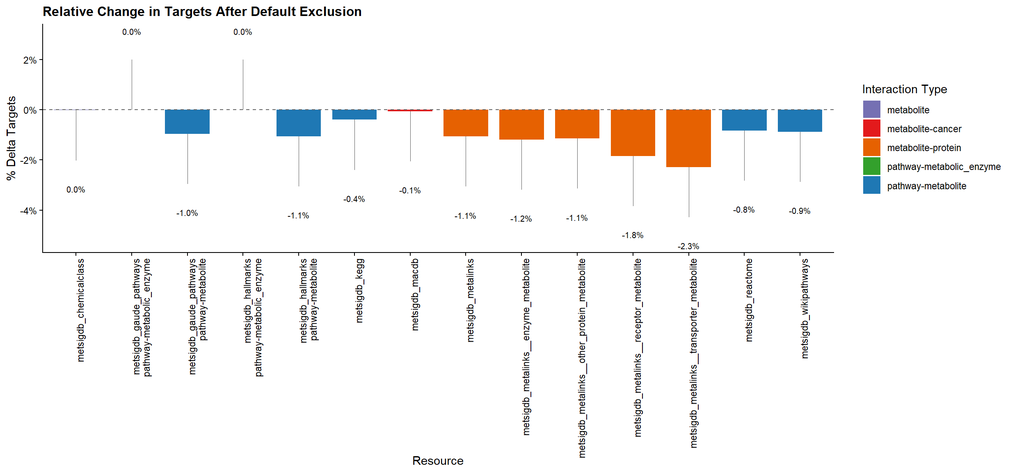

```r
p_delta_targets
```

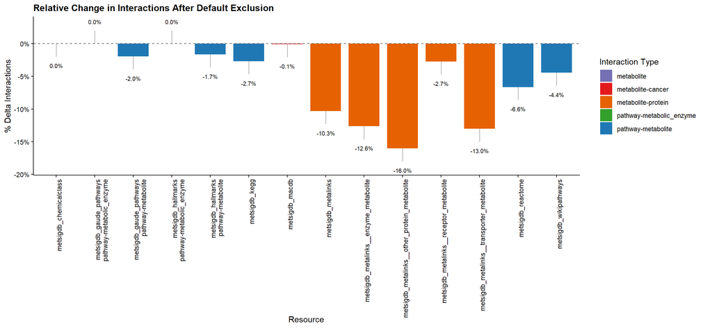

```r
p_delta_interactions
```

# 6 Test 1: Resource level summary

The table below summarizes overall resource footprint under default exclusion. It reports distinct terms, distinct targets, interactions, and average connectivity metrics.

```r
knitr::kable(tbl_resource_level, digits = 3)
```

| Resource | Resource Group | Interaction Type | Distinct Terms | Distinct Targets | Distinct Interactions | Avg Targets per Term | Avg Terms per Target |
| --- | --- | --- | --- | --- | --- | --- | --- |
| metsigdb_chemicalclass | Annotation resources | metabolite | 410 | 145820 | 145820 | 355.659 | 1.000 |
| metsigdb_macdb | Cancer association resources | metabolite-cancer | 212 | 5404 | 17939 | 84.618 | 3.320 |
| metsigdb_gaude_pathways | Derived pathway resources | pathway-metabolic_enzyme | 96 | 1453 | 1932 | 20.125 | 1.330 |
| metsigdb_gaude_pathways | Derived pathway resources | pathway-metabolite | 90 | 822 | 3822 | 42.467 | 4.650 |
| metsigdb_hallmarks | Derived pathway resources | pathway-metabolic_enzyme | 50 | 4384 | 7322 | 146.440 | 1.670 |
| metsigdb_hallmarks | Derived pathway resources | pathway-metabolite | 48 | 753 | 4536 | 94.500 | 6.024 |
| metsigdb_metalinks | Interaction resources | metabolite-protein | 3585 | 1116 | 24500 | 6.834 | 21.953 |
| metsigdb_metalinks__enzyme_metabolite | Interaction resources | metabolite-protein | 825 | 584 | 3654 | 4.429 | 6.257 |
| metsigdb_metalinks__other_protein_metabolite | Interaction resources | metabolite-protein | 1691 | 777 | 8282 | 4.898 | 10.659 |
| metsigdb_metalinks__receptor_metabolite | Interaction resources | metabolite-protein | 671 | 373 | 9558 | 14.244 | 25.625 |
| metsigdb_metalinks__transporter_metabolite | Interaction resources | metabolite-protein | 481 | 385 | 3067 | 6.376 | 7.966 |
| metsigdb_kegg | Pathway resources | pathway-metabolite | 452 | 6586 | 18935 | 41.892 | 2.875 |
| metsigdb_reactome | Pathway resources | pathway-metabolite | 19827 | 3129 | 277313 | 13.987 | 88.627 |
| metsigdb_wikipathways | Pathway resources | pathway-metabolite | 1288 | 6896 | 15573 | 12.091 | 2.258 |

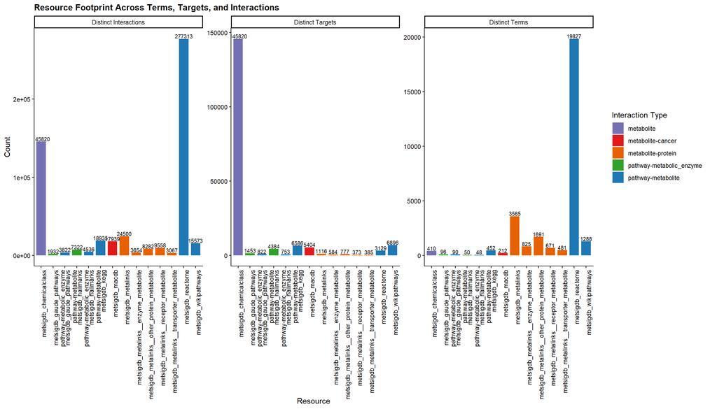

```r
p_resource_footprint
```

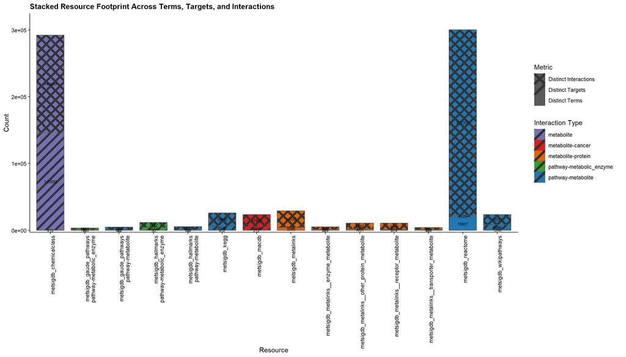

```r
p_resource_footprint_stacked
```

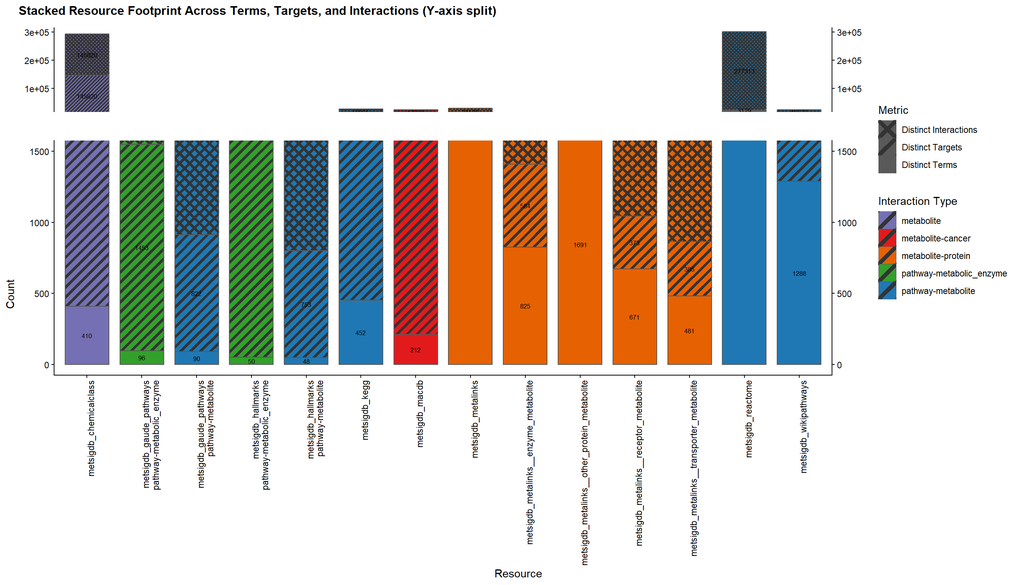

```r
p_resource_footprint_stacked_split
```

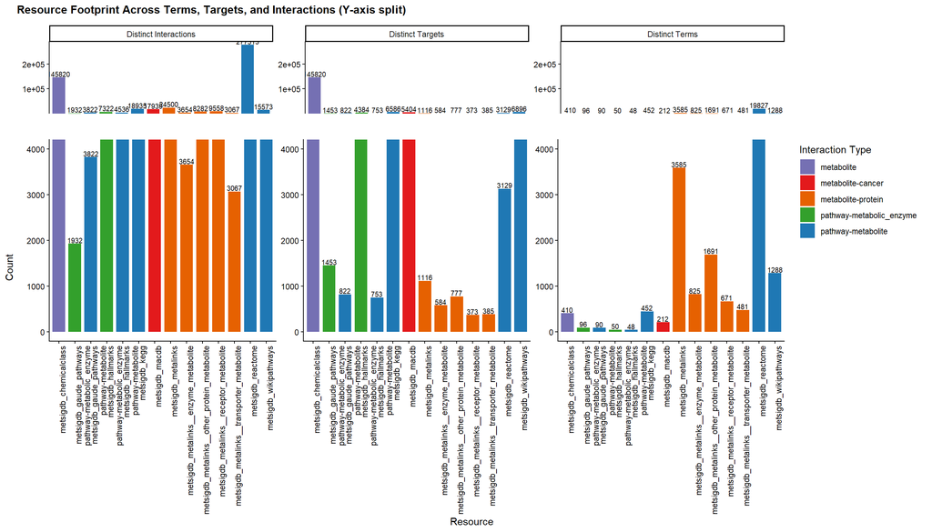

```r
p_resource_footprint_split
```

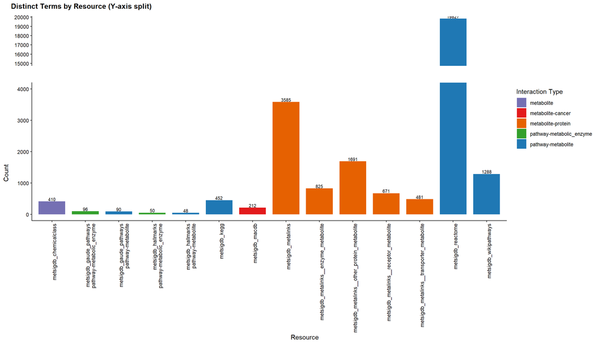

```r
p_resource_footprint_terms_split
```

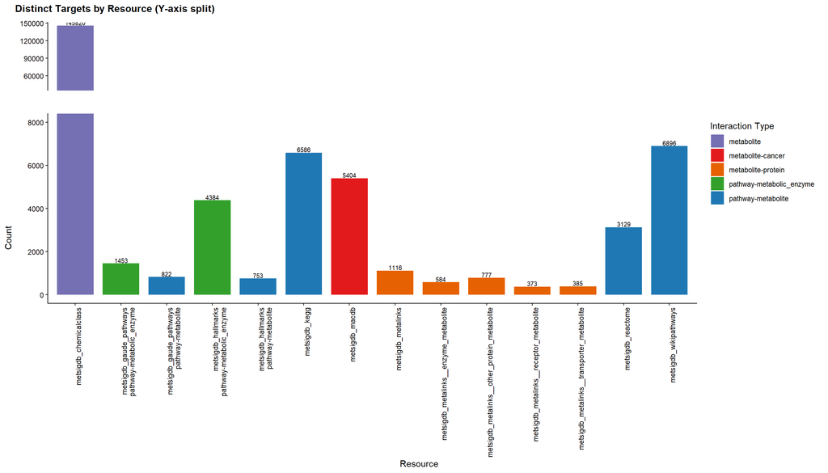

```r
p_resource_footprint_targets_split
```

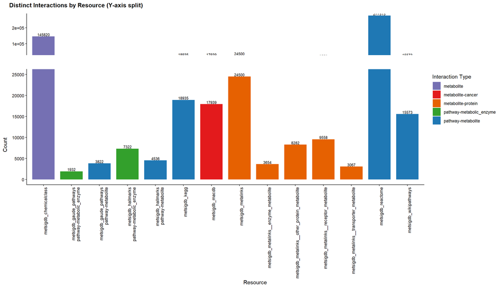

```r
p_resource_footprint_interactions_split
```

# 7 Test 2: Term size distribution

The table below describes term size distributions. Use mean/median targets per term to compare how broad resources are.

```r
knitr::kable(tbl_set_level, digits = 3)
```

| Resource | Resource Group | Interaction Type | Min Targets per Term | Median Targets per Term | Mean Targets per Term | Max Targets per Term |
| --- | --- | --- | --- | --- | --- | --- |
| metsigdb_chemicalclass | Annotation resources | metabolite | 1 | 10.0 | 355.659 | 62599 |
| metsigdb_macdb | Cancer association resources | metabolite-cancer | 1 | 24.0 | 84.221 | 1659 |
| metsigdb_gaude_pathways | Derived pathway resources | pathway-metabolic_enzyme | 1 | 15.5 | 20.125 | 82 |
| metsigdb_gaude_pathways | Derived pathway resources | pathway-metabolite | 1 | 21.5 | 42.467 | 199 |
| metsigdb_hallmarks | Derived pathway resources | pathway-metabolic_enzyme | 32 | 180.0 | 146.440 | 200 |
| metsigdb_hallmarks | Derived pathway resources | pathway-metabolite | 1 | 56.0 | 94.500 | 362 |
| metsigdb_metalinks | Interaction resources | metabolite-protein | 1 | 2.0 | 6.834 | 90 |
| metsigdb_metalinks__enzyme_metabolite | Interaction resources | metabolite-protein | 1 | 2.0 | 4.429 | 56 |
| metsigdb_metalinks__other_protein_metabolite | Interaction resources | metabolite-protein | 1 | 2.0 | 4.898 | 89 |
| metsigdb_metalinks__receptor_metabolite | Interaction resources | metabolite-protein | 1 | 4.0 | 14.244 | 65 |
| metsigdb_metalinks__transporter_metabolite | Interaction resources | metabolite-protein | 1 | 3.0 | 6.376 | 90 |
| metsigdb_kegg | Pathway resources | pathway-metabolite | 1 | 11.0 | 41.892 | 3219 |
| metsigdb_reactome | Pathway resources | pathway-metabolite | 1 | 5.0 | 13.987 | 1622 |
| metsigdb_wikipathways | Pathway resources | pathway-metabolite | 1 | 7.0 | 12.091 | 470 |

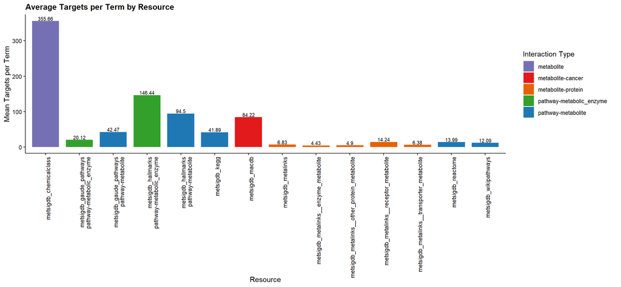

```r
p_set_level_mean
```

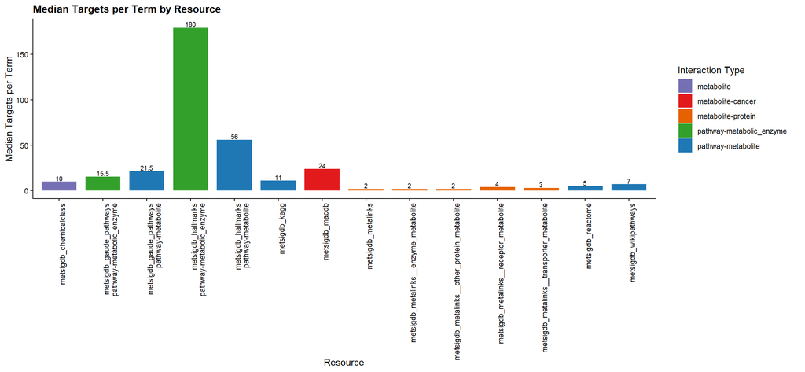

```r
p_set_level_median
```

# 8 Test 3: Target membership buckets

The next table shows how often targets recur across terms. The stacked plot highlights whether resources are dominated by single-term or multi-term targets.

```r
knitr::kable(tbl_degree_buckets, digits = 3)
```

| Resource | Resource Group | Interaction Type | Membership Bucket | Number of Targets | Share of Targets |
| --- | --- | --- | --- | --- | --- |
| metsigdb_chemicalclass | Annotation resources | metabolite | in 1 term | 145820 | 1.000 |
| metsigdb_macdb | Cancer association resources | metabolite-cancer | in 1 term | 3067 | 0.568 |
| metsigdb_macdb | Cancer association resources | metabolite-cancer | in 2 terms | 805 | 0.149 |
| metsigdb_macdb | Cancer association resources | metabolite-cancer | in >2 terms | 1532 | 0.283 |
| metsigdb_gaude_pathways | Derived pathway resources | pathway-metabolic_enzyme | in 1 term | 1206 | 0.830 |
| metsigdb_gaude_pathways | Derived pathway resources | pathway-metabolic_enzyme | in 2 terms | 147 | 0.101 |
| metsigdb_gaude_pathways | Derived pathway resources | pathway-metabolic_enzyme | in >2 terms | 100 | 0.069 |
| metsigdb_gaude_pathways | Derived pathway resources | pathway-metabolite | in 1 term | 208 | 0.253 |
| metsigdb_gaude_pathways | Derived pathway resources | pathway-metabolite | in 2 terms | 135 | 0.164 |
| metsigdb_gaude_pathways | Derived pathway resources | pathway-metabolite | in >2 terms | 479 | 0.583 |
| metsigdb_hallmarks | Derived pathway resources | pathway-metabolic_enzyme | in 1 term | 2671 | 0.609 |
| metsigdb_hallmarks | Derived pathway resources | pathway-metabolic_enzyme | in 2 terms | 1002 | 0.229 |
| metsigdb_hallmarks | Derived pathway resources | pathway-metabolic_enzyme | in >2 terms | 711 | 0.162 |
| metsigdb_hallmarks | Derived pathway resources | pathway-metabolite | in 1 term | 95 | 0.126 |
| metsigdb_hallmarks | Derived pathway resources | pathway-metabolite | in 2 terms | 118 | 0.157 |
| metsigdb_hallmarks | Derived pathway resources | pathway-metabolite | in >2 terms | 540 | 0.717 |
| metsigdb_metalinks | Interaction resources | metabolite-protein | in 1 term | 220 | 0.197 |
| metsigdb_metalinks | Interaction resources | metabolite-protein | in 2 terms | 109 | 0.098 |
| metsigdb_metalinks | Interaction resources | metabolite-protein | in >2 terms | 787 | 0.705 |
| metsigdb_metalinks__enzyme_metabolite | Interaction resources | metabolite-protein | in 1 term | 209 | 0.358 |
| metsigdb_metalinks__enzyme_metabolite | Interaction resources | metabolite-protein | in 2 terms | 93 | 0.159 |
| metsigdb_metalinks__enzyme_metabolite | Interaction resources | metabolite-protein | in >2 terms | 282 | 0.483 |
| metsigdb_metalinks__other_protein_metabolite | Interaction resources | metabolite-protein | in 1 term | 177 | 0.228 |
| metsigdb_metalinks__other_protein_metabolite | Interaction resources | metabolite-protein | in 2 terms | 103 | 0.133 |
| metsigdb_metalinks__other_protein_metabolite | Interaction resources | metabolite-protein | in >2 terms | 497 | 0.640 |
| metsigdb_metalinks__receptor_metabolite | Interaction resources | metabolite-protein | in 1 term | 130 | 0.349 |
| metsigdb_metalinks__receptor_metabolite | Interaction resources | metabolite-protein | in 2 terms | 51 | 0.137 |
| metsigdb_metalinks__receptor_metabolite | Interaction resources | metabolite-protein | in >2 terms | 192 | 0.515 |
| metsigdb_metalinks__transporter_metabolite | Interaction resources | metabolite-protein | in 1 term | 75 | 0.195 |
| metsigdb_metalinks__transporter_metabolite | Interaction resources | metabolite-protein | in 2 terms | 47 | 0.122 |
| metsigdb_metalinks__transporter_metabolite | Interaction resources | metabolite-protein | in >2 terms | 263 | 0.683 |
| metsigdb_kegg | Pathway resources | pathway-metabolite | in 1 term | 1636 | 0.248 |
| metsigdb_kegg | Pathway resources | pathway-metabolite | in 2 terms | 2048 | 0.311 |
| metsigdb_kegg | Pathway resources | pathway-metabolite | in >2 terms | 2902 | 0.441 |
| metsigdb_reactome | Pathway resources | pathway-metabolite | in 2 terms | 26 | 0.008 |
| metsigdb_reactome | Pathway resources | pathway-metabolite | in >2 terms | 3103 | 0.992 |
| metsigdb_wikipathways | Pathway resources | pathway-metabolite | in 1 term | 4462 | 0.647 |
| metsigdb_wikipathways | Pathway resources | pathway-metabolite | in 2 terms | 1121 | 0.163 |
| metsigdb_wikipathways | Pathway resources | pathway-metabolite | in >2 terms | 1313 | 0.190 |

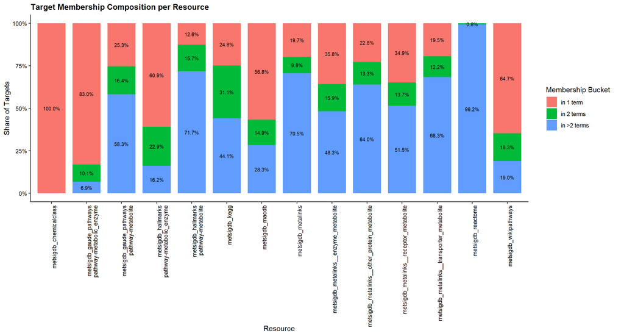

```r
p_degree_bucket
```

# 9 Export summary

The paths below show where all exported artifacts were written for this run.

```r
export_summary_tbl <- tibble::tribble(
  ~Artifact, ~Path,
  "Excel workbook", excel_file,
  "Plot directory", plots_dir
)

knitr::kable(export_summary_tbl)
```

| Artifact | Path |
| --- | --- |
| Excel workbook | D:/Masterarbeit_LOCAL/MetaProViz/PriorKnowledge/MetSigDB_Benchmark/benchmark_results/metsigdb_benchmark_20260407_170252/metsigdb_benchmark_20260407_170252.xlsx |
| Plot directory | D:/Masterarbeit_LOCAL/MetaProViz/PriorKnowledge/MetSigDB_Benchmark/benchmark_results/metsigdb_benchmark_20260407_170252/plots |

# 10 References

Agrawal, A. et al. 2024. “WikiPathways 2024: Next Generation Pathway Database.” *Nucleic Acids Research* 52: D679–89.

Braisted, J. et al. 2023. “RaMP-DB 2.0: A Renovated Knowledgebase for Deriving Biological and Chemical Insight from Metabolites, Proteins, and Genes.” *Bioinformatics* 39.

Djoumbou Feunang, Yannick, Roman Eisner, Craig Knox, Leonid Chepelev, Janna Hastings, Gareth Owen, Eoin Fahy, et al. 2016. “ClassyFire: Automated Chemical Classification with a Comprehensive, Computable Taxonomy.” *Journal of Cheminformatics* 8: 61. https://doi.org/10.1186/s13321-016-0174-y.

Farr, Elias, Daniel Dimitrov, Christina Schmidt, Denes Turei, Sebastian Lobentanzer, Aurelien Dugourd, and Julio Saez-Rodriguez. 2024. “MetaLinksDB: A Flexible and Contextualizable Resource of Metabolite-Protein Interactions.” *Briefings in Bioinformatics* 25 (4): bbae347. https://doi.org/10.1093/bib/bbae347.

Kanehisa, Minoru, Miho Furumichi, Mao Tanabe, Yoko Sato, and Kanae Morishima. 2017. “KEGG: New Perspectives on Genomes, Pathways, Diseases and Drugs.” *Nucleic Acids Research* 45: D353–61.

Milacic, Marija et al. 2024. “The Reactome Pathway Knowledgebase 2024.” *Nucleic Acids Research*.

Sun, Y., X. Zheng, G. Wang, Y. Wang, X. Chen, J. Sun, Z. Xiong, et al. 2023. “MACdb: A Curated Knowledgebase for Metabolic Associations Across Human Cancers.” *Molecular Cancer Research* 21 (7): 691–97. https://doi.org/10.1158/1541-7786.MCR-22-0909.

Turei, Denes, Albert Valdeolivas, Leyla Gul, Nicolas Palacio-Escat, Michal Klein, Olga Ivanova, Mihaela Olbei, et al. 2021. “Integrated Intra- and Intercellular Signaling Knowledge for Multicellular Omics Analysis.” *Molecular Systems Biology* 17: e9923. https://doi.org/10.15252/msb.20209923.